# Weighting for online surveys

Georges Monette

2016-09-13

# Introduction

This document gives examples using of a few tools for survey analysis in an R package called WWCa. The package borrows from and is inspired by the WWC package.

Currently, the package contains:

1. Two ‘population’ data frames with census counts by county for the U.S. and Puerto Rico. One data frame has counts for age, sex and raceethnicity by county and the second (to come) has counts for age, sex and education by county. **Q: Is is possible to get a sex by age by education by raceethnicity data frame?** These data frames were constructed from the ‘acsagetable’ and ‘acsedutable’ data frames in the [WWC package](https://github.com/heathermkrause/WWC).
2. A function ‘sam’ to create simulated samples from the population data frames. The function accepts a sampling factor to allow over- or undersampling in arbitrary strata. Currently, the response is binary and the probability of a ‘yes’ can also be specified in any strata. **In the works: Arbitrary parameters and distributions, multiple responses.**
3. A number of data manipulation utilities adapted from the [spida2 package](https://github.com/gmonette/spida2). The main functions are ‘tab’ and ‘tab_df’ to create marginal frequency and population counts in a way that preserves ordered factors. Other functions include ‘spida2::capply’, an addition to the ‘apply’ family that allows function to operate within each stratum and return a single value or a vector value within each stratum.
4. Functions for weighting and calculating weighted and unweighted estimates of population parameters. All estimates and standard errors are currently computed within the function ‘est’.  
   Other estimators can be added to this function.

## Overview of estimation functions

The basis of survey weights are population and sample counts within strata and the ratio of these two counts, the Horvitz-Thompson weights. The ‘wts’ function computes these quantities.

The structure of the functions should make it easy to add additional weight fitting methods and to identify nested hierarchies of subpopulations for which a sample can provide estimates with different levels of reliability.

The ‘wtd_mean’ function estimates a weighted mean and a companion function ‘jk_wtd_mean_se’ estimates a jacknife estimate of its standard error. The functions ‘lin_comb’ and ‘jk_lin_comb_se’ provide corresponding estimates for linear combinations.

## To Do

1. add arbitrary distributions for response.
2. explore sample size: the simulation below uses a sample size of 100.
3. extend methods to calculate and apply survey weights so they can include raking and generalized regression, etc.
4. develop method to identify nested sets of contiguous strata according to sampling ratio. This will allow the description of a nested set of increasingly large subpopulations for which there is decreasing precision in estimation.

## A tool to quickly view data frames

info’ is a method to look at data frames. It could be extended to other classes. It can be inserted in a magrittr (%>%) pipeline.

```r
info <- function(x, ...) UseMethod('info')
info.data.frame <- function(x, n = 6, verbose = FALSE, ...) {
  cat("Dim: ",dim(x),"\n")
  if(nrow(x) <= n) print(x)
  else print(x[sample(nrow(x), n),])
  if(verbose >= 1) print(sapply(x,class))
  invisible(x)
}
info.default <- function(x,...) {
  cat("Not implemented for ", class(x),"\n")
  invisible(x)
}
info_ <- function(x,...) info(x, ..., verbose = 1)
```

# Algorithms

## Computing population and sample counts

To weight a survey we may need to specify a target population – for example, the population of a specific state, the voting age population of a given subset of states, adult females between 18 and 65, etc. – and we need to identify the variables to be used for adjustment – for example, sex and age, sex and raceethnicity, age and state, etc.

Including variables for adjustment reduces bias to the extent that

1. the variables are related to the response, **and**
2. the distribution of the variables in the sample is different from that in the population.

Since there are so many possible combinations of target subpopulations and choices of variables for adjustment, it would seem easier, if it can be done efficiently, to have a function that creates a population count data frame for any specified target and set of adjustment variables.

The data frame ‘popagetable’ in this package was created from ‘acsagetable’ in ‘WWC’ by keeping the rows corresponding to the finest level of aggregation, the ‘county’ level, and creating variables for ‘state’ (50 states plus DC and PR for Puerto Rico) and ‘country’ (US or PR).

A number of negative population counts for categories in counties were imputed to 0. The original population count variable with negative values is named ‘population_neg’.

The following examples show how the ‘subset’ function (in the base package) combined with ‘tab’ and ‘tab_df’ (in WWCa), which are modified version of ‘table’ (in base), can be used to create population – or subpopulation – counts for various choices of stratification variables.

```r
popagetable %>% info
```

```
Dim:  450800 10
       country state state.code county    sex            age                       raceethnicity
155066      US    KY      KY-21  21231   Male   5 to 9 years                  HISPANIC OR LATINO
435270      US    WI      WI-55  55141   Male 35 to 44 years WHITE ALONE, NOT HISPANIC OR LATINO
265541      US    NC      NC-37  37075 Female 45 to 54 years                  HISPANIC OR LATINO
255891      US    NM      NM-35  35057   Male   5 to 9 years                         ASIAN ALONE
419931      US    WV      WV-54  54041 Female  Under 5 years WHITE ALONE, NOT HISPANIC OR LATINO
423398      US    WV      WV-54  54029   Male  Under 5 years                         ASIAN ALONE
       population population_neg date
155066         38             38   NA
435270       3971           3971   NA
265541          5              5   NA
255891          0              0   NA
419931        439            439   NA
423398          0              0   NA
```

Number of rows in each stratume

```r
popagetable %>% tab(~age + sex)
```

```
                   sex
age                 Female   Male  Total
  Under 5 years      16100  16100  32200
  5 to 9 years       16100  16100  32200
  10 to 14 years     16100  16100  32200
  15 to 17 years     16100  16100  32200
  18 and 19 years    16100  16100  32200
  20 to 24 years     16100  16100  32200
  25 to 29 years     16100  16100  32200
  30 to 34 years     16100  16100  32200
  35 to 44 years     16100  16100  32200
  45 to 54 years     16100  16100  32200
  55 to 64 years     16100  16100  32200
  65 to 74 years     16100  16100  32200
  75 to 84 years     16100  16100  32200
  85 years and over  16100  16100  32200
  Total             225400 225400 450800
```

Population in each stratum

```r
popagetable %>% tab(population ~ age + sex)
```

```
                   sex
age                    Female      Male     Total
  Under 5 years       9876664  10320908  20197572
  5 to 9 years       10140174  10562533  20702707
  10 to 14 years     10243486  10729983  20973469
  15 to 17 years      6248440   6573474  12821914
  18 and 19 years     4376866   4611462   8988328
  20 to 24 years     11090519  11610509  22701028
  25 to 29 years     10731308  10972693  21704001
  30 to 34 years     10544197  10583903  21128100
  35 to 44 years     20724386  20517143  41241529
  45 to 54 years     22745028  22037209  44782237
  55 to 64 years     20259070  18827127  39086197
  65 to 74 years     12998807  11364438  24363245
  75 to 84 years      7787414   5774913  13562327
  85 years and over   3931100   1964883   5895983
  Total             161697459 156451178 318148637
```

Row percentages

```r
popagetable %>% tab(population ~ age + sex, pct = 1)   %>% round(1)
```

```
                   sex
age                 Female  Male Total
  Under 5 years       48.9  51.1 100.0
  5 to 9 years        49.0  51.0 100.0
  10 to 14 years      48.8  51.2 100.0
  15 to 17 years      48.7  51.3 100.0
  18 and 19 years     48.7  51.3 100.0
  20 to 24 years      48.9  51.1 100.0
  25 to 29 years      49.4  50.6 100.0
  30 to 34 years      49.9  50.1 100.0
  35 to 44 years      50.3  49.7 100.0
  45 to 54 years      50.8  49.2 100.0
  55 to 64 years      51.8  48.2 100.0
  65 to 74 years      53.4  46.6 100.0
  75 to 84 years      57.4  42.6 100.0
  85 years and over   66.7  33.3 100.0
  All                 50.8  49.2 100.0
```

Column percentages

```r
popagetable %>% tab(population ~ age + sex, pct = 2)   %>% round(1)
```

```
                   sex
age                 Female  Male   All
  Under 5 years        6.1   6.6   6.3
  5 to 9 years         6.3   6.8   6.5
  10 to 14 years       6.3   6.9   6.6
  15 to 17 years       3.9   4.2   4.0
  18 and 19 years      2.7   2.9   2.8
  20 to 24 years       6.9   7.4   7.1
  25 to 29 years       6.6   7.0   6.8
  30 to 34 years       6.5   6.8   6.6
  35 to 44 years      12.8  13.1  13.0
  45 to 54 years      14.1  14.1  14.1
  55 to 64 years      12.5  12.0  12.3
  65 to 74 years       8.0   7.3   7.7
  75 to 84 years       4.8   3.7   4.3
  85 years and over    2.4   1.3   1.9
  Total              100.0 100.0 100.0
```

As a data frame

```r
popagetable %>% tab_df(population ~age + sex)
```

```
                 age    sex population
1      Under 5 years Female    9876664
2       5 to 9 years Female   10140174
3     10 to 14 years Female   10243486
4     15 to 17 years Female    6248440
5    18 and 19 years Female    4376866
6     20 to 24 years Female   11090519
7     25 to 29 years Female   10731308
8     30 to 34 years Female   10544197
9     35 to 44 years Female   20724386
10    45 to 54 years Female   22745028
11    55 to 64 years Female   20259070
12    65 to 74 years Female   12998807
13    75 to 84 years Female    7787414
14 85 years and over Female    3931100
15     Under 5 years   Male   10320908
16      5 to 9 years   Male   10562533
17    10 to 14 years   Male   10729983
18    15 to 17 years   Male    6573474
19   18 and 19 years   Male    4611462
20    20 to 24 years   Male   11610509
21    25 to 29 years   Male   10972693
22    30 to 34 years   Male   10583903
23    35 to 44 years   Male   20517143
24    45 to 54 years   Male   22037209
25    55 to 64 years   Male   18827127
26    65 to 74 years   Male   11364438
27    75 to 84 years   Male    5774913
28 85 years and over   Male    1964883
```

Data frame with percentages: note that ‘All’ is included but not ‘Total’

```r
popagetable %>% tab_df(population ~age + sex, pct = 1)
```

```
                 age    sex population
1      Under 5 years Female   48.90025
2       5 to 9 years Female   48.97994
3     10 to 14 years Female   48.84021
4     15 to 17 years Female   48.73251
5    18 and 19 years Female   48.69500
6     20 to 24 years Female   48.85470
7     25 to 29 years Female   49.44392
8     30 to 34 years Female   49.90604
9     35 to 44 years Female   50.25126
10    45 to 54 years Female   50.79029
11    55 to 64 years Female   51.83178
12    65 to 74 years Female   53.35417
13    75 to 84 years Female   57.41945
14 85 years and over Female   66.67421
```

[output cut: 16 more lines]

## Negative and zero population values

Overall, about 1% of rows (strata x county combinations) have negative population values and 30% have zero values.

```r
popagetable %>% tab(~state + sign(population_neg))
```

```
       sign(population_neg)
state       -1      0      1  Total
  AK         0   1334   2726   4060
  AL        59   2320   7001   9380
  AR        53   3360   7087  10500
  AZ         5    239   1856   2100
  CA        12    633   7475   8120
  CO        29   3253   5678   8960
  CT         4     20   1096   1120
  DC         0      0    140    140
  DE         4      4    412    420
  FL       121   1083   8176   9380
  GA       230   6307  15723  22260
  HI         1    139    560    700
  IA        43   5388   8429  13860
  ID        12   2484   3664   6160
  IL        53   4203  10024  14280
  IN        45   4058   8777  12880
  KS        28   6087   8585  14700
  KY        42   7031   9727  16800
  LA        45   1961   6954   8960
  MA         6    130   1824   1960
  MD        27    242   3091   3360
  ME         0    429   1811   2240
  MI        18   2286   9316  11620
  MN        30   3302   8848  12180
  MO        35   5733  10332  16100
  MS       113   4015   7352  11480
  MT         3   4009   3828   7840
  NC        79   2516  11405  14000
  ND         3   3978   3439   7420
  NE        30   6760   6230  13020
  NH         3    243   1154   1400
  NJ        61     40   2839   2940
  NM        17   1385   3218   4620
  NV         3    701   1676   2380
  NY       137    746   7797   8680
  OH        24   2517   9779  12320
  OK         8   2363   8409  10780
  OR        10   1166   3864   5040
  PA        77   1261   8042   9380
  RI         4     37    659    700
  SC        63   1191   5186   6440
  SD         8   4804   4428   9240
  TN        41   4052   9207  13300
  TX       355  10938  24267  35560
  UT         0   1434   2626   4060
  VA       128   4971  13521  18620
  VT         4    466   1490   1960
  WA        10    959   4491   5460
  WI        16   2129   7935  10080
  WV        14   3433   4253   7700
  WY         6   1300   1914   3220
  PR      1773   4085   5062  10920
  Total   3892 133525 313383 450800
```

```r
popagetable %>% tab(~state + sign(population_neg), pct = 1) %>% round(1)
```

```
     sign(population_neg)
state    -1     0     1 Total
  AK    0.0  32.9  67.1 100.0
  AL    0.6  24.7  74.6 100.0
  AR    0.5  32.0  67.5 100.0
  AZ    0.2  11.4  88.4 100.0
  CA    0.1   7.8  92.1 100.0
  CO    0.3  36.3  63.4 100.0
  CT    0.4   1.8  97.9 100.0
  DC    0.0   0.0 100.0 100.0
  DE    1.0   1.0  98.1 100.0
  FL    1.3  11.5  87.2 100.0
  GA    1.0  28.3  70.6 100.0
  HI    0.1  19.9  80.0 100.0
  IA    0.3  38.9  60.8 100.0
  ID    0.2  40.3  59.5 100.0
  IL    0.4  29.4  70.2 100.0
  IN    0.3  31.5  68.1 100.0
  KS    0.2  41.4  58.4 100.0
  KY    0.2  41.9  57.9 100.0
  LA    0.5  21.9  77.6 100.0
  MA    0.3   6.6  93.1 100.0
  MD    0.8   7.2  92.0 100.0
  ME    0.0  19.2  80.8 100.0
  MI    0.2  19.7  80.2 100.0
  MN    0.2  27.1  72.6 100.0
  MO    0.2  35.6  64.2 100.0
  MS    1.0  35.0  64.0 100.0
  MT    0.0  51.1  48.8 100.0
  NC    0.6  18.0  81.5 100.0
  ND    0.0  53.6  46.3 100.0
  NE    0.2  51.9  47.8 100.0
  NH    0.2  17.4  82.4 100.0
  NJ    2.1   1.4  96.6 100.0
  NM    0.4  30.0  69.7 100.0
  NV    0.1  29.5  70.4 100.0
  NY    1.6   8.6  89.8 100.0
  OH    0.2  20.4  79.4 100.0
  OK    0.1  21.9  78.0 100.0
  OR    0.2  23.1  76.7 100.0
  PA    0.8  13.4  85.7 100.0
  RI    0.6   5.3  94.1 100.0
  SC    1.0  18.5  80.5 100.0
  SD    0.1  52.0  47.9 100.0
  TN    0.3  30.5  69.2 100.0
  TX    1.0  30.8  68.2 100.0
  UT    0.0  35.3  64.7 100.0
  VA    0.7  26.7  72.6 100.0
  VT    0.2  23.8  76.0 100.0
  WA    0.2  17.6  82.3 100.0
  WI    0.2  21.1  78.7 100.0
  WV    0.2  44.6  55.2 100.0
  WY    0.2  40.4  59.4 100.0
  PR   16.2  37.4  46.4 100.0
  All   0.9  29.6  69.5 100.0
```

Aggregating over counties, at the state level all the negative values occur for ‘raceethnicity’ equal to ‘OTHER’ in Puerto Rico.

```r
popagetable %>%
  tab_df(population_neg ~ sex + age + raceethnicity + state) %>%
  subset(population_neg < 10)
```

```
        sex               age                   raceethnicity state population_neg
980    Male 85 years and over                           OTHER    CT              9
1876   Male 85 years and over BLACK OR AFRICAN AMERICAN ALONE    ID              4
2995 Female 85 years and over BLACK OR AFRICAN AMERICAN ALONE    ME              0
2996   Male 85 years and over BLACK OR AFRICAN AMERICAN ALONE    ME              5
3694   Male    75 to 84 years BLACK OR AFRICAN AMERICAN ALONE    MT              9
3695 Female 85 years and over BLACK OR AFRICAN AMERICAN ALONE    MT              0
3696   Male 85 years and over BLACK OR AFRICAN AMERICAN ALONE    MT              0
3947 Female 85 years and over                     ASIAN ALONE    ND              3
3948   Male 85 years and over                     ASIAN ALONE    ND              0
3973 Female    75 to 84 years BLACK OR AFRICAN AMERICAN ALONE    ND              0
3975 Female 85 years and over BLACK OR AFRICAN AMERICAN ALONE    ND              0
3976   Male 85 years and over BLACK OR AFRICAN AMERICAN ALONE    ND              0
5767 Female 85 years and over                     ASIAN ALONE    SD              0
5768   Male 85 years and over                     ASIAN ALONE    SD              0
```

[output cut: 33 more lines]

Focusing on California

```r
popagetable %>% subset(state == "CA")  %>% tab(population ~ age + sex)
```

```
                   sex
age                   Female     Male    Total
  Under 5 years      1233171  1288147  2521318
  5 to 9 years       1239346  1291849  2531195
  10 to 14 years     1247469  1304704  2552173
  15 to 17 years      783535   824086  1607621
  18 and 19 years     532860   568699  1101559
  20 to 24 years     1391338  1495875  2887213
  25 to 29 years     1364649  1450748  2815397
  30 to 34 years     1325894  1371950  2697844
  35 to 44 years     2580005  2595683  5175688
  45 to 54 years     2637150  2611326  5248476
  55 to 64 years     2228501  2082098  4310599
  65 to 74 years     1366910  1186153  2553063
  75 to 84 years      804703   612809  1417512
  85 years and over   419890   227482   647372
  Total             19155421 18911609 38067030
```

Sex distribution by age group:

```r
popagetable %>% subset(state == "CA")  %>% tab(population ~ age + sex, pct = 1) %>% round(2)
```

```
                   sex
age                 Female   Male  Total
  Under 5 years      48.91  51.09 100.00
  5 to 9 years       48.96  51.04 100.00
  10 to 14 years     48.88  51.12 100.00
  15 to 17 years     48.74  51.26 100.00
  18 and 19 years    48.37  51.63 100.00
  20 to 24 years     48.19  51.81 100.00
  25 to 29 years     48.47  51.53 100.00
  30 to 34 years     49.15  50.85 100.00
  35 to 44 years     49.85  50.15 100.00
  45 to 54 years     50.25  49.75 100.00
  55 to 64 years     51.70  48.30 100.00
  65 to 74 years     53.54  46.46 100.00
  75 to 84 years     56.77  43.23 100.00
  85 years and over  64.86  35.14 100.00
  All                50.32  49.68 100.00
```

Age distribution by sex:

```r
popagetable %>% subset(state == "CA")  %>% tab(population ~ age + sex, pct = 2) %>% round(2)
```

```
                   sex
age                 Female   Male    All
  Under 5 years       6.44   6.81   6.62
  5 to 9 years        6.47   6.83   6.65
  10 to 14 years      6.51   6.90   6.70
  15 to 17 years      4.09   4.36   4.22
  18 and 19 years     2.78   3.01   2.89
  20 to 24 years      7.26   7.91   7.58
  25 to 29 years      7.12   7.67   7.40
  30 to 34 years      6.92   7.25   7.09
  35 to 44 years     13.47  13.73  13.60
  45 to 54 years     13.77  13.81  13.79
  55 to 64 years     11.63  11.01  11.32
  65 to 74 years      7.14   6.27   6.71
  75 to 84 years      4.20   3.24   3.72
  85 years and over   2.19   1.20   1.70
  Total             100.00 100.00 100.00
```

Percentage in each stratum (cell):

```r
popagetable %>% subset(state == "CA")  %>% tab(population ~ age + sex, pct = 0) %>% round(2)
```

```
                   sex
age                 Female   Male  Total
  Under 5 years       3.24   3.38   6.62
  5 to 9 years        3.26   3.39   6.65
  10 to 14 years      3.28   3.43   6.70
  15 to 17 years      2.06   2.16   4.22
  18 and 19 years     1.40   1.49   2.89
  20 to 24 years      3.65   3.93   7.58
  25 to 29 years      3.58   3.81   7.40
  30 to 34 years      3.48   3.60   7.09
  35 to 44 years      6.78   6.82  13.60
  45 to 54 years      6.93   6.86  13.79
  55 to 64 years      5.85   5.47  11.32
  65 to 74 years      3.59   3.12   6.71
  75 to 84 years      2.11   1.61   3.72
  85 years and over   1.10   0.60   1.70
  Total              50.32  49.68 100.00
```

Population by stratum as a data frame:

```r
popagetable %>% subset(state == "CA")  %>% tab_df(population ~ age + sex)    # as a data frame
```

```
                 age    sex population
1      Under 5 years Female    1233171
2       5 to 9 years Female    1239346
3     10 to 14 years Female    1247469
4     15 to 17 years Female     783535
5    18 and 19 years Female     532860
6     20 to 24 years Female    1391338
7     25 to 29 years Female    1364649
8     30 to 34 years Female    1325894
9     35 to 44 years Female    2580005
10    45 to 54 years Female    2637150
11    55 to 64 years Female    2228501
12    65 to 74 years Female    1366910
13    75 to 84 years Female     804703
14 85 years and over Female     419890
15     Under 5 years   Male    1288147
16      5 to 9 years   Male    1291849
17    10 to 14 years   Male    1304704
18    15 to 17 years   Male     824086
19   18 and 19 years   Male     568699
20    20 to 24 years   Male    1495875
21    25 to 29 years   Male    1450748
22    30 to 34 years   Male    1371950
23    35 to 44 years   Male    2595683
24    45 to 54 years   Male    2611326
25    55 to 64 years   Male    2082098
26    65 to 74 years   Male    1186153
27    75 to 84 years   Male     612809
28 85 years and over   Male     227482
```

Selecting a subset: female adults in NY and PA below 85 years of age. Note that age is an ordered factor.

```r
targetdf <- popagetable %>%
  subset(state %in% c('NY','PA') &
           sex == "Female" &
           age > "15 to 17 years" &
           age < "85 years and over") %>%
  tab_df(population ~ age + sex + state)
targetdf
```

```
               age    sex state population
1  18 and 19 years Female    NY     274613
2   20 to 24 years Female    NY     714044
3   25 to 29 years Female    NY     720843
4   30 to 34 years Female    NY     676964
5   35 to 44 years Female    NY    1303686
6   45 to 54 years Female    NY    1467148
7   55 to 64 years Female    NY    1272515
8   65 to 74 years Female    NY     813280
9   75 to 84 years Female    NY     511785
10 18 and 19 years Female    PA     187196
11  20 to 24 years Female    PA     431807
12  25 to 29 years Female    PA     403094
13  30 to 34 years Female    PA     381301
14  35 to 44 years Female    PA     782473
15  45 to 54 years Female    PA     952525
16  55 to 64 years Female    PA     878968
17  65 to 74 years Female    PA     569423
18  75 to 84 years Female    PA     388269
```

```r
targetdf$age
```

```
 [1] 18 and 19 years 20 to 24 years  25 to 29 years  30 to 34 years  35 to 44 years  45 to 54 years
 [7] 55 to 64 years  65 to 74 years  75 to 84 years  18 and 19 years 20 to 24 years  25 to 29 years
[13] 30 to 34 years  35 to 44 years  45 to 54 years  55 to 64 years  65 to 74 years  75 to 84 years
14 Levels: Under 5 years < 5 to 9 years < 10 to 14 years < 15 to 17 years < ... < 85 years and over
```

# Creating a sample

Here, we create a sample using basic tools with the intention of packaging the method in a function.

To control the extent of over- and under-sampling, we generate a vector ‘fac’ to determine relative sampling from each stratum.

We suppose that the response variable has two values, ‘yes’ or ‘no’, and that the probability of a ‘yes’ depends on age and sex but not on raceethnicity. The probability of a ‘yes’ will be contained in a vector ‘pr’.

We consider the consequences of adjusting for various combinations of the three variables.

The questionnaire will solicit information on raceethnicity, sex, age and state but not on county.

## Step 1: Create a population data frame, aggregated over counties, with sampling parameters

Aggregate to state level:

```r
pop_agg <- popagetable %>% tab_df(population ~ sex + age + raceethnicity + state)
pop_agg %>% info
```

```
Dim:  7280 5
        sex            age                       raceethnicity state population
4435 Female 20 to 24 years WHITE ALONE, NOT HISPANIC OR LATINO    NJ     134643
3595 Female 20 to 24 years WHITE ALONE, NOT HISPANIC OR LATINO    MS      56173
3893 Female  Under 5 years                               OTHER    NC      19086
2861 Female 10 to 14 years                  HISPANIC OR LATINO    MD      19964
3530   Male  Under 5 years     BLACK OR AFRICAN AMERICAN ALONE    MS      43837
4455 Female   5 to 9 years                               OTHER    NJ       7207
```

```r
pop_agg %>% summary
```

```
     sex                    age                                   raceethnicity      state
 Female:3640   Under 5 years  : 520   ASIAN ALONE                        :1456   AK     : 140
 Male  :3640   5 to 9 years   : 520   BLACK OR AFRICAN AMERICAN ALONE    :1456   AL     : 140
               10 to 14 years : 520   HISPANIC OR LATINO                 :1456   AR     : 140
               15 to 17 years : 520   WHITE ALONE, NOT HISPANIC OR LATINO:1456   AZ     : 140
               18 and 19 years: 520   OTHER                              :1456   CA     : 140
               20 to 24 years : 520                                              CO     : 140
               (Other)        :4160                                              (Other):6440
   population
 Min.   :      0
 1st Qu.:   1762
 Median :   8325
 Mean   :  43702
 3rd Qu.:  37355
 Max.   :1195382
```

Select main group targeted and assign values for sampling parameters

```r
sample_parms <- subset(pop_agg, state == 'CA' & age > "18 and 19 years" & age < '65 to 74 years') %>%
  tab_df(~ sex + age + state)
sample_parms %>% dim
```

```
[1] 12  4
```

```r
sample_parms
```

```
      sex            age state Freq
1  Female 20 to 24 years    CA    5
2    Male 20 to 24 years    CA    5
3  Female 25 to 29 years    CA    5
4    Male 25 to 29 years    CA    5
5  Female 30 to 34 years    CA    5
6    Male 30 to 34 years    CA    5
7  Female 35 to 44 years    CA    5
8    Male 35 to 44 years    CA    5
9  Female 45 to 54 years    CA    5
10   Male 45 to 54 years    CA    5
11 Female 55 to 64 years    CA    5
12   Male 55 to 64 years    CA    5
```

Assign sampling factor and probability of a yes:

To illustrate the possibility of having non-independent selection probabilities accross stratification variables, we pretend that the sample is disproportionaly young among women and old among men by creating a relative sampling factor in a data frame with sex by age combinations. Since the sampling factors and the response distribution don’t depend on ethnicity, we don’t take that into account at this stage.

```r
sample_parms$Freq <- NULL
sample_parms$fac <- c(3,2,2,1,1,1,1,1,1,2,2,3)  # relative sampling factor
sample_parms$pr <- c(4,2,1,1,1,.5,.5,1,1,1,3,4)/5  # probability of a YES
sample_parms
```

```
      sex            age state fac  pr
1  Female 20 to 24 years    CA   3 0.8
2    Male 20 to 24 years    CA   2 0.4
3  Female 25 to 29 years    CA   2 0.2
4    Male 25 to 29 years    CA   1 0.2
5  Female 30 to 34 years    CA   1 0.2
6    Male 30 to 34 years    CA   1 0.1
7  Female 35 to 44 years    CA   1 0.1
8    Male 35 to 44 years    CA   1 0.2
9  Female 45 to 54 years    CA   1 0.2
10   Male 45 to 54 years    CA   2 0.2
11 Female 55 to 64 years    CA   2 0.6
12   Male 55 to 64 years    CA   3 0.8
```

Merge into sampling data frame and assign values to remaining ‘fac’ and ‘pr’

```r
pop_agg <- merge(pop_agg, sample_parms, all.x = T)
pop_agg %>% summary
```

```
     sex                    age           state                                  raceethnicity
 Female:3640   Under 5 years  : 520   AK     : 140   ASIAN ALONE                        :1456
 Male  :3640   5 to 9 years   : 520   AL     : 140   BLACK OR AFRICAN AMERICAN ALONE    :1456
               10 to 14 years : 520   AR     : 140   HISPANIC OR LATINO                 :1456
               15 to 17 years : 520   AZ     : 140   WHITE ALONE, NOT HISPANIC OR LATINO:1456
               18 and 19 years: 520   CA     : 140   OTHER                              :1456
               20 to 24 years : 520   CO     : 140
               (Other)        :4160   (Other):6440
   population           fac              pr
 Min.   :      0   Min.   :1.000   Min.   :0.100
 1st Qu.:   1762   1st Qu.:1.000   1st Qu.:0.200
 Median :   8325   Median :1.500   Median :0.200
 Mean   :  43702   Mean   :1.667   Mean   :0.333
 3rd Qu.:  37355   3rd Qu.:2.000   3rd Qu.:0.450
 Max.   :1195382   Max.   :3.000   Max.   :0.800
                   NA's   :7220    NA's   :7220
```

Assign a small sampling ratio for strata that are ‘out of scope’:

```r
pop_agg$fac[is.na(pop_agg$fac)] <- 0.01
pop_agg$pr[is.na(pop_agg$pr)] <- 0.5
pop_agg %>% summary
```

```
     sex                    age           state                                  raceethnicity
 Female:3640   Under 5 years  : 520   AK     : 140   ASIAN ALONE                        :1456
 Male  :3640   5 to 9 years   : 520   AL     : 140   BLACK OR AFRICAN AMERICAN ALONE    :1456
               10 to 14 years : 520   AR     : 140   HISPANIC OR LATINO                 :1456
               15 to 17 years : 520   AZ     : 140   WHITE ALONE, NOT HISPANIC OR LATINO:1456
               18 and 19 years: 520   CA     : 140   OTHER                              :1456
               20 to 24 years : 520   CO     : 140
               (Other)        :4160   (Other):6440
   population           fac                pr
 Min.   :      0   Min.   :0.01000   Min.   :0.1000
 1st Qu.:   1762   1st Qu.:0.01000   1st Qu.:0.5000
 Median :   8325   Median :0.01000   Median :0.5000
 Mean   :  43702   Mean   :0.02365   Mean   :0.4986
 3rd Qu.:  37355   3rd Qu.:0.01000   3rd Qu.:0.5000
 Max.   :1195382   Max.   :3.00000   Max.   :0.8000
```

## Step 2: Sample respondents

Take a sample of N = 1000 with probabilities proportional to population proportion times ‘fac’

```r
N <- 1000
pop_agg$prob <- with(pop_agg, population * fac)
```

We use the ‘sample’ function with selection probabilities proportional to the population in each stratum time the relative sampling factor. Note that the relative sampling factors do not need to sum to 1.

```r
sample_rows <- sample(nrow(pop_agg), N, replace = T, prob = pop_agg$prob)
```

Create sample data frame

```r
sample <- pop_agg[sample_rows,]
sample %>% info
```

```
Dim:  1000 8
           sex            age state                       raceethnicity population fac  pr    prob
1321.14 Female 20 to 24 years    CA                  HISPANIC OR LATINO     622327   3 0.8 1866981
1845    Female 30 to 34 years    CA     BLACK OR AFRICAN AMERICAN ALONE      76240   1 0.2   76240
6004.21   Male 45 to 54 years    CA WHITE ALONE, NOT HISPANIC OR LATINO    1195382   2 0.2 2390764
1585.3  Female 25 to 29 years    CA WHITE ALONE, NOT HISPANIC OR LATINO     466925   2 0.2  933850
6001.36   Male 45 to 54 years    CA                  HISPANIC OR LATINO     835323   2 0.2 1670646
6265.15   Male 55 to 64 years    CA                  HISPANIC OR LATINO     486815   3 0.8 1460445
```

```r
sample %>% tab(~state == 'CA')
```

```
state == "CA"
FALSE  TRUE Total
   68   932  1000
```

## Step 3: Generate response

```r
sample$y <- rbinom(nrow(sample), 1, prob = sample$pr)
```

We can get rid of information we would not normally have in a sample, although this informaiton is useful to assess the properties of a simulation.

```r
sample <- subset(sample, select = c(sex, age, raceethnicity, state, y)) # keeps all the rows, selects columns
sample %>% info
```

```
Dim:  1000 5
           sex            age                       raceethnicity state y
2623.41 Female 55 to 64 years WHITE ALONE, NOT HISPANIC OR LATINO    CA 0
2361.13 Female 45 to 54 years WHITE ALONE, NOT HISPANIC OR LATINO    CA 0
1844.5  Female 30 to 34 years WHITE ALONE, NOT HISPANIC OR LATINO    CA 0
1321.26 Female 20 to 24 years                  HISPANIC OR LATINO    CA 1
1585.4  Female 25 to 29 years WHITE ALONE, NOT HISPANIC OR LATINO    CA 0
5743.3    Male 35 to 44 years                         ASIAN ALONE    CA 0
```

## Sampling function

We can put the series of steps together in a sampling function

```r
sam <- function(N = 1,
                pop = popagetable, # population frequency table
                fmla = population ~ sex + age + raceethnicity + state, # aggregation formula
                subset, # an expression that selects a subset, e.g. state == 'AK' & age > '5 to 9 years'
                fac, # a data frame or list of data frames to assign relative sampling frequencies,
                    # variable names are the RHS names in 'fmla' and 'fac', a numeric sampling factor
                   # If 'fac' is a list, the factors are applied multiplicatively
                prob) # same as fac except that prob. of a 'yes' is given in variable 'prob'. They are
                      # combined by summing log odds
                    # TO BE GENERALIZED!!
{
  # Note: reserved names: fac, prob, y
  # local functions
  last <- function(x) x[length(x)]
  na2 <- function(x, rep = 0) {
    x[is.na(x)] <- rep
    x
  }
  # sampling frame
  sampling_frame <- tab_df(pop, fmla)
  library(magrittr) # for pipes
  strat_vars <- fmla %>%
    as.character %>%
    last %>%
    gsub(" ","",.) %>%
    strsplit("[*+/:]") %>%
    unlist

  if(!missing(subset)) { # code from 'subset.data.frame'
    e <- substitute(subset)
    r <- eval(e, sampling_frame, parent.frame())
    if(!is.logical(r)) stop("'subset' must be logical")
    sampling_frame <- sampling_frame[r & !is.na(r),]
  }
  # sampling factor
  sampling_frame$fac <-1
  if(!missing(fac)) {
    if(is.data.frame(fac)) fac <- list(fac)
    fac <- lapply(fac, function(d) d[,c(intersect(names(d),strat_vars),'fac')])
    for(dd in fac){
      sampling_frame <- merge(sampling_frame, dd, all.x = T, by = intersect(strat_vars, names(dd)))
      sampling_frame$fac <- sampling_frame$fac.x * na2(sampling_frame$fac.y, 1)
      sampling_frame$fac.y <- NULL
      sampling_frame$fac.x <- NULL
    }
  }
  # probability of a 'yes'
  logit <- function(p) log(p/(1-p))
  sampling_frame$logit <- 0
  if(!missing(prob)) {
    if(is.data.frame(prob)) prob <- list(prob)
    prob <- lapply(prob, function(d) d[,c(intersect(names(d),strat_vars),'prob')])
    for(dd in prob){
      dd$logit <- logit(dd$prob)
      dd$prob <- NULL
      sampling_frame <- merge(sampling_frame, dd, all.x = T, by = intersect(strat_vars, names(dd)))
      sampling_frame$logit <- sampling_frame$logit.x + na2(sampling_frame$logit.y, 0)
      sampling_frame$logit.y <- NULL
      sampling_frame$logit.x <- NULL
    }
  }
  sampling_frame$prob <- 1/(1+exp(-sampling_frame$logit))

  # select respondents

  rows <- sample(nrow(sampling_frame), N, replace = TRUE,
                 prob = with(sampling_frame, population * fac))
  sample <- sampling_frame[rows,]

  # Generate response

  sample$y <- rbinom(nrow(sample), 1, prob = sample$prob)
  attr(sample,'fmla') <- fmla
  attr(sample,'strat_vars') <- strat_vars
  sample
}
```

### Examples

A simple random sample from the population, default probability of ‘yes’ is 0.5:

```r
sam(5)
```

```
        sex            age                       raceethnicity state population fac logit prob y
1781 Female 35 to 44 years WHITE ALONE, NOT HISPANIC OR LATINO    IA     155911   1     0  0.5 1
4443 Female 45 to 54 years WHITE ALONE, NOT HISPANIC OR LATINO    NJ     431884   1     0  0.5 1
6806   Male  Under 5 years WHITE ALONE, NOT HISPANIC OR LATINO    WI     124289   1     0  0.5 0
3183 Female 45 to 54 years WHITE ALONE, NOT HISPANIC OR LATINO    MI     587065   1     0  0.5 1
5355 Female 15 to 17 years     BLACK OR AFRICAN AMERICAN ALONE    PA      32899   1     0  0.5 0
```

A simple random sample of women recording only age

```r
sam(5, fmla = population ~ sex + age, subset = sex == "Female")
```

```
        sex               age population fac logit prob y
17   Female    35 to 44 years   20724386   1     0  0.5 1
19   Female    45 to 54 years   22745028   1     0  0.5 1
21   Female    55 to 64 years   20259070   1     0  0.5 0
27   Female 85 years and over    3931100   1     0  0.5 1
17.1 Female    35 to 44 years   20724386   1     0  0.5 0
```

A simple random sample of women recording age and state

```r
sam(5, fmla = population ~ sex + age + state, subset = sex == "Female")
```

```
          sex            age state population fac logit prob y
1223   Female 45 to 54 years    TX    1739688   1     0  0.5 1
1363   Female 45 to 54 years    WI     424546   1     0  0.5 1
1223.1 Female 45 to 54 years    TX    1739688   1     0  0.5 0
1083   Female 45 to 54 years    PA     952525   1     0  0.5 1
995    Female 30 to 34 years    OH     357503   1     0  0.5 0
```

A biased sample with the probability of a ‘yes’ depending on sex

```r
fac <- list(
  data.frame(sex = c('Male','Female'), fac = c(3,2)), # with no omitted level, these are relative sampling factors
  data.frame(age = "20 to 24 years", fac = 5)   # omitted levels are set to 1
)
fac
```

```
[[1]]
     sex fac
1   Male   3
2 Female   2

[[2]]
             age fac
1 20 to 24 years   5
```

```r
prob <- data.frame(sex = 'Male', prob = .8) # the omitted level 'Female' defaults to .5
prob
```

```
   sex prob
1 Male  0.8
```

```r
sam(5, fmla = population ~ sex + age + state, fac = fac, prob = prob)
```

```
         sex            age state population fac    logit prob y
677   Female 55 to 64 years    TX    1447225   2 0.000000  0.5 1
1059    Male 25 to 29 years    MO     200080   3 1.386294  0.8 1
677.1 Female 55 to 64 years    TX    1447225   2 0.000000  0.5 0
1092    Male 55 to 64 years    ME      97554   3 1.386294  0.8 1
552   Female 45 to 54 years    IN     463901   2 0.000000  0.5 1
```

A similar sample limited to California and recording raceethnicity as well

```r
sam(5, fmla = population ~ sex + age + raceethnicity + state, subset = state == "CA",
    fac = fac, prob = prob)
```

```
       sex            age                       raceethnicity state population fac    logit prob y
135   Male 55 to 64 years WHITE ALONE, NOT HISPANIC OR LATINO    CA    1140943   3 1.386294  0.8 1
104   Male 30 to 34 years                  HISPANIC OR LATINO    CA     587407   3 1.386294  0.8 0
30  Female 35 to 44 years     BLACK OR AFRICAN AMERICAN ALONE    CA     149776   2 0.000000  0.5 1
59  Female 35 to 44 years WHITE ALONE, NOT HISPANIC OR LATINO    CA     888631   2 0.000000  0.5 1
75    Male  Under 5 years WHITE ALONE, NOT HISPANIC OR LATINO    CA     327389   3 1.386294  0.8 1
```

Oversampling teen males

```r
(fac <- tab_df(popagetable, ~ age + sex)) %>% info
```

```
Dim:  28 3
                 age    sex  Freq
15     Under 5 years   Male 16100
26    65 to 74 years   Male 16100
17    10 to 14 years   Male 16100
7     25 to 29 years Female 16100
28 85 years and over   Male 16100
25    55 to 64 years   Male 16100
```

```r
fac$Freq <- NULL
fac$fac <- c(0,0,rep(1,12), 0,0, 10, 20, 20, 10, 5, rep(1,7))
fac
```

```
                 age    sex fac
1      Under 5 years Female   0
2       5 to 9 years Female   0
3     10 to 14 years Female   1
4     15 to 17 years Female   1
5    18 and 19 years Female   1
6     20 to 24 years Female   1
7     25 to 29 years Female   1
8     30 to 34 years Female   1
9     35 to 44 years Female   1
10    45 to 54 years Female   1
11    55 to 64 years Female   1
12    65 to 74 years Female   1
13    75 to 84 years Female   1
14 85 years and over Female   1
15     Under 5 years   Male   0
16      5 to 9 years   Male   0
17    10 to 14 years   Male  10
18    15 to 17 years   Male  20
19   18 and 19 years   Male  20
20    20 to 24 years   Male  10
21    25 to 29 years   Male   5
22    30 to 34 years   Male   1
23    35 to 44 years   Male   1
24    45 to 54 years   Male   1
25    55 to 64 years   Male   1
26    65 to 74 years   Male   1
27    75 to 84 years   Male   1
28 85 years and over   Male   1
```

```r
sam(5, fmla = population ~ sex + age, fac = fac, prob = prob)
```

```
      sex               age population fac    logit prob y
7  Female    35 to 44 years   20724386   1 0.000000  0.5 1
15   Male    10 to 14 years   10729983  10 1.386294  0.8 1
16   Male    15 to 17 years    6573474  20 1.386294  0.8 0
13 Female 85 years and over    3931100   1 0.000000  0.5 1
19   Male    25 to 29 years   10972693   5 1.386294  0.8 0
```

### A larger sample: exploring some properties

```r
(subset_expr <- quote(state == 'AK' & age > "18 and 19 years" & age < '65 to 74 years'))
```

```
state == "AK" & age > "18 and 19 years" & age < "65 to 74 years"
```

```r
(target_pop <- subset(popagetable, eval(subset_expr))) %>% info
```

```
Dim:  1740 10
      country state state.code county    sex            age                       raceethnicity
10054      US    AK      AK-02  02013 Female 20 to 24 years     BLACK OR AFRICAN AMERICAN ALONE
10771      US    AK      AK-02  02068 Female 35 to 44 years     BLACK OR AFRICAN AMERICAN ALONE
11529      US    AK      AK-02  02090 Female 30 to 34 years                         ASIAN ALONE
13221      US    AK      AK-02  02150   Male 45 to 54 years WHITE ALONE, NOT HISPANIC OR LATINO
10248      US    AK      AK-02  02282   Male 45 to 54 years                         ASIAN ALONE
10250      US    AK      AK-02  02270 Female 30 to 34 years                         ASIAN ALONE
      population population_neg date
10054          5              5   NA
10771          0              0   NA
11529        130            130   NA
13221        600            600   NA
10248         11             11   NA
10250          0              0   NA
```

```r
fac <- popagetable %>%
  subset(eval(subset_expr)) %>%
  tab_df(~age + sex)
fac$Freq <- NULL
fac$fac <-  c(3,2,2,1,1,1,1,1,1,2,2,3)  # relative sampling factor
fac$prob <- c(4,2,1,1,1,.5,.5,1,1,1,3,4)/5  # probability of a YES
fac
```

```
              age    sex fac prob
1  20 to 24 years Female   3  0.8
2  25 to 29 years Female   2  0.4
3  30 to 34 years Female   2  0.2
4  35 to 44 years Female   1  0.2
5  45 to 54 years Female   1  0.2
6  55 to 64 years Female   1  0.1
7  20 to 24 years   Male   1  0.1
8  25 to 29 years   Male   1  0.2
9  30 to 34 years   Male   1  0.2
10 35 to 44 years   Male   2  0.2
11 45 to 54 years   Male   2  0.6
12 55 to 64 years   Male   3  0.8
```

```r
sample <- sam(1000, fmla = population ~ age + sex + state + raceethnicity,
              subset = eval(subset_expr),
              fac = fac,
              prob = fac)
sample %>% info
```

```
Dim:  1000 9
                  age    sex state                       raceethnicity population fac      logit
12.3   25 to 29 years Female    AK                               OTHER       6364   2 -0.4054651
56.116 55 to 64 years   Male    AK WHITE ALONE, NOT HISPANIC OR LATINO      36634   3  1.3862944
1.5    20 to 24 years Female    AK                         ASIAN ALONE       1582   3  1.3862944
47.62  45 to 54 years   Male    AK WHITE ALONE, NOT HISPANIC OR LATINO      38549   2  0.4054651
13.44  25 to 29 years Female    AK WHITE ALONE, NOT HISPANIC OR LATINO      16778   2 -0.4054651
45.9   45 to 54 years Female    AK                               OTHER       8922   1 -1.3862944
       prob y
12.3    0.4 0
56.116  0.8 1
1.5     0.8 1
47.62   0.6 1
13.44   0.4 0
45.9    0.2 0
```

Exploring the sample

```r
sample %>% tab(~age+sex)
```

```
                sex
age              Female Male Total
  20 to 24 years    103   37   140
  25 to 29 years     83   46   129
  30 to 34 years     71   31   102
  35 to 44 years     57  113   170
  45 to 54 years     63  135   198
  55 to 64 years     63  198   261
  Total             440  560  1000
```

```r
sample %>% tab(~age+sex, pct = 0) %>% round(1)
```

```
                sex
age              Female  Male Total
  20 to 24 years   10.3   3.7  14.0
  25 to 29 years    8.3   4.6  12.9
  30 to 34 years    7.1   3.1  10.2
  35 to 44 years    5.7  11.3  17.0
  45 to 54 years    6.3  13.5  19.8
  55 to 64 years    6.3  19.8  26.1
  Total            44.0  56.0 100.0
```

```r
sample %>% tab(~age+sex, pct = 1) %>% round(1)
```

```
                sex
age              Female  Male Total
  20 to 24 years   73.6  26.4 100.0
  25 to 29 years   64.3  35.7 100.0
  30 to 34 years   69.6  30.4 100.0
  35 to 44 years   33.5  66.5 100.0
  45 to 54 years   31.8  68.2 100.0
  55 to 64 years   24.1  75.9 100.0
  All              44.0  56.0 100.0
```

```r
sample %>% tab(~age+sex, pct = 2) %>% round(1)
```

```
                sex
age              Female  Male   All
  20 to 24 years   23.4   6.6  14.0
  25 to 29 years   18.9   8.2  12.9
  30 to 34 years   16.1   5.5  10.2
  35 to 44 years   13.0  20.2  17.0
  45 to 54 years   14.3  24.1  19.8
  55 to 64 years   14.3  35.4  26.1
  Total           100.0 100.0 100.0
```

Over and undersampling

Proportion in target population and sampling ratio

```r
(target_prop <- target_pop %>% tab(population~age+sex, pct = 0)) %>% round(1)
```

```
                sex
age              Female  Male Total
  20 to 24 years    5.7   7.4  13.1
  25 to 29 years    6.0   6.9  12.9
  30 to 34 years    5.4   5.9  11.3
  35 to 44 years    9.6  10.5  20.2
  45 to 54 years   10.9  11.7  22.6
  55 to 64 years    9.5  10.4  19.9
  Total            47.2  52.8 100.0
```

```r
(sampling_ratio <- tab(sample, ~ age + sex, pct = 0) / target_prop) %>% round(2)
```

```
                sex
age              Female Male Total
  20 to 24 years   1.80 0.50  1.07
  25 to 29 years   1.38 0.67  1.00
  30 to 34 years   1.31 0.52  0.90
  35 to 44 years   0.59 1.07  0.84
  45 to 54 years   0.58 1.15  0.87
  55 to 64 years   0.67 1.90  1.31
  Total            0.93 1.06  1.00
```

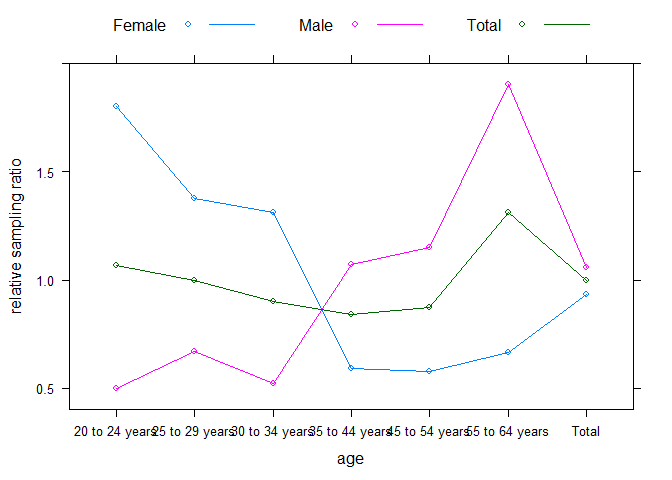

```r
xyplot(Freq~age , as.data.frame(sampling_ratio), groups = sex, type = 'b',
       ylab = 'relative sampling ratio',
       auto.key = list(columns = 3, lines = T))
```

Percent of YES responses within each group

```r
(100 * tab(sample, y ~ age + sex)/tab(sample, ~age + sex))  %>% round(1)
```

```
                sex
age              Female Male Total
  20 to 24 years   81.6 18.9  65.0
  25 to 29 years   39.8 26.1  34.9
  30 to 34 years   18.3 16.1  17.6
  35 to 44 years   12.3 15.9  14.7
  45 to 54 years   23.8 63.7  51.0
  55 to 64 years    9.5 83.3  65.5
  Total            35.9 52.3  45.1
```

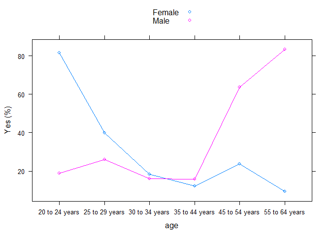

```r
(100 * tab_(sample, y ~ age + sex)/tab_(sample, ~age + sex))  %>% as.data.frame(responseName="Yes") -> sample_as
xyplot(Yes ~ age ,sample_as, groups = sex, type = 'b', auto.key = T, ylab ='Yes (%)')
```

make plots nicer, i.e. more like ggplot2

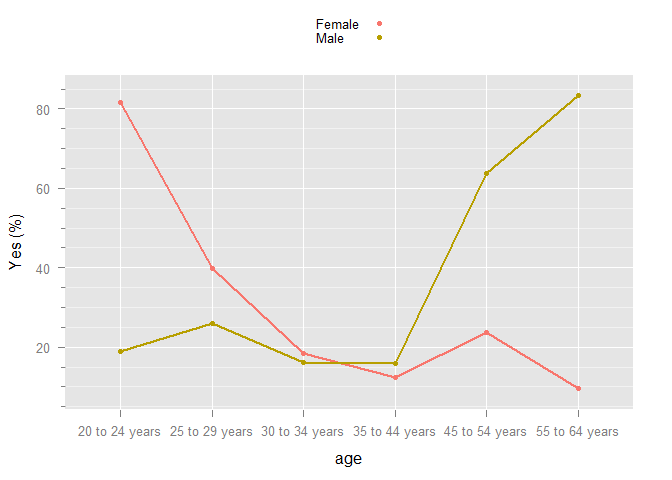

```r
trellis.par.set(ggplot2like())
lattice.options(ggplot2like.opts())
xyplot(Yes ~ age ,sample_as, groups = sex, type = 'b', lwd = 2, auto.key = T, ylab ='Yes (%)')
```

## Estimating the probability of YES

‘True’ value in the target population:

```r
fac
```

```
              age    sex fac prob
1  20 to 24 years Female   3  0.8
2  25 to 29 years Female   2  0.4
3  30 to 34 years Female   2  0.2
4  35 to 44 years Female   1  0.2
5  45 to 54 years Female   1  0.2
6  55 to 64 years Female   1  0.1
7  20 to 24 years   Male   1  0.1
8  25 to 29 years   Male   1  0.2
9  30 to 34 years   Male   1  0.2
10 35 to 44 years   Male   2  0.2
11 45 to 54 years   Male   2  0.6
12 55 to 64 years   Male   3  0.8
```

```r
fac_pop <- tab_df(target_pop, population ~ age + sex)
fac <- merge(fac, fac_pop)
fac %>% with(wtd_mean(prob,population))
```

```
[1] 0.3388253
```

Estimated value from the sample without weighing

```r
sample %>% with(mean(y))
```

```
[1] 0.451
```

Estimated std. error:

```r
sample %>% with(sd(y)/sqrt(length(y)))
```

```
[1] 0.01574315
```

## Creating weights for the sample

Weights depend on the choice of variables to create strata. Within each stratum, we need the population count and the sample count.

This seems easiest to do with a simple function:

```r
ns <- function(sample, target_pop, formula) {
  # The sample and the target_pop data frames
  # must include the variables used in the formula of the
  # form, e.g. ~ sex + age.
  #
  # The variable 'population' is assumed to give
  # population counts in each row of 'target_pop'
  #
  # The function returns a data frame like 'sample'
  # with two added variables: n and N for the sample
  # and population counts respectively.
  ret <- sample
  by <- model.frame(formula, sample)
  # sample counts: WWCa::capply(x, by, FUN, ...) applies the function 'FUN'
  ret$n <- capply(ret[[1]], by, length)
  # population counts
  pop <- tab_df(target_pop, formula, weight = target_pop$population)
  pop$N <- pop$Freq
  pop$Freq <- NULL
  ret <- merge(ret,pop, all = T)
  fac.names <- names(pop)[sapply(pop,is.factor)]
  for(nn in fac.names) {
    ret[[nn]] <- factor(ret[[nn]],levels=levels(pop[[nn]]))
    if(is.ordered(pop[[nn]])) ret[[nn]] <- ordered(ret[[nn]])
  }
  ret$n[is.na(ret$n)] <- 0
  ret
}
sample_as <- ns(sample, target_pop, ~ age + sex)
sample_as %>% info
```

```
Dim:  1000 11
               age    sex state                       raceethnicity population fac      logit prob
209 25 to 29 years Female    AK                  HISPANIC OR LATINO       2058   2 -0.4054651  0.4
878 55 to 64 years   Male    AK                               OTHER       6057   3  1.3862944  0.8
113 20 to 24 years   Male    AK WHITE ALONE, NOT HISPANIC OR LATINO      19603   1 -2.1972246  0.1
357 30 to 34 years   Male    AK WHITE ALONE, NOT HISPANIC OR LATINO      17744   1 -1.3862944  0.2
945 55 to 64 years   Male    AK                  HISPANIC OR LATINO       1388   3  1.3862944  0.8
419 35 to 44 years Female    AK WHITE ALONE, NOT HISPANIC OR LATINO      28428   1 -1.3862944  0.2
    y   n     N
209 0  83 27646
878 1 198 47659
113 0  37 33785
357 1  31 27144
945 1 198 47659
419 0  57 44004
```

# Weights

## Horvitz-Thompson and related weights

```r
HTwts <- function(sample, cap = 3) {
  # sample with n and N
  ret <- sample
  ret$HT <- with(sample, N/n)
  ret$HTcap <- pmin(ret$HT, cap)
  ret$HT_mean <- ret$HT/mean(ret$HT)
  ret$HT_med <- ret$HT/median(ret$HT)
  ret$HT_mean_cap <- pmin(ret$HT_mean, cap)
  ret$HT_med_cap <- pmin(ret$HT_med, cap)
  ret$none <- 1
  ret
}
```

```r
(sample_asw <- HTwts(sample_as)) %>% info
```

```
Dim:  1000 18
               age    sex state                       raceethnicity population fac     logit prob y
823 55 to 64 years   Male    AK WHITE ALONE, NOT HISPANIC OR LATINO      36634   3  1.386294  0.8 1
16  20 to 24 years Female    AK WHITE ALONE, NOT HISPANIC OR LATINO      14450   3  1.386294  0.8 1
455 35 to 44 years   Male    AK                  HISPANIC OR LATINO       2978   2 -1.386294  0.2 0
284 30 to 34 years Female    AK WHITE ALONE, NOT HISPANIC OR LATINO      15538   2 -1.386294  0.2 0
123 20 to 24 years   Male    AK                               OTHER       7528   1 -2.197225  0.1 1
343 30 to 34 years   Male    AK WHITE ALONE, NOT HISPANIC OR LATINO      17744   1 -1.386294  0.2 0
      n     N       HT HTcap   HT_mean    HT_med HT_mean_cap HT_med_cap none
823 198 47659 240.7020     3 0.5254998 0.6054099   0.5254998  0.6054099    1
16  103 26181 254.1845     3 0.5549346 0.6393208   0.5549346  0.6393208    1
455 113 48317 427.5841     3 0.9335000 1.0754527   0.9335000  1.0754527    1
284  71 24784 349.0704     3 0.7620893 0.8779764   0.7620893  0.8779764    1
123  37 33785 913.1081     3 1.9934943 2.2966351   1.9934943  2.2966351    1
343  31 27144 875.6129     3 1.9116349 2.2023278   1.9116349  2.2023278    1
```

```r
sample_asw %>% with(wtd_mean(y,HT))
```

```
[1] 0.3469279
```

```r
sample_asw %>% with(jk_wtd_mean_se(y,list(age,sex),HT))
```

```
[1] 0.01380897
```

```r
sample_asw %>% with(wtd_mean(y,HT_mean_cap))
```

```
[1] 0.3469279
```

```r
sample_asw %>% with(jk_wtd_mean_se(y,list(age,sex),HT_mean_cap))
```

```
[1] 0.01380897
```

Using only sex for adjustment

```r
sample_sw <- sample %>% ns(target_pop, ~sex) %>% HTwts
sample_sw %>% with(wtd_mean(y, HT))
```

```
[1] 0.4458239
```

```r
sample_sw %>% with(jk_wtd_mean_se(y, list(sex), HT))
```

```
[1] 0.01553043
```

```r
sample_sw %>% with(wtd_mean(y, HT_mean_cap))
```

```
[1] 0.4458239
```

```r
sample_sw %>% with(jk_wtd_mean_se(y,list(sex),HT_mean_cap))
```

```
[1] 0.01553043
```

Using only age for adjustment

```r
sample_aw <- sample %>% ns(target_pop, ~age) %>% HTwts
sample_aw %>% with(wtd_mean(y,HT))
```

```
[1] 0.4254316
```

```r
sample_aw %>% with(jk_wtd_mean_se(y,list(age),HT))
```

```
[1] 0.0143379
```

```r
sample_aw %>% with(wtd_mean(y,HT_mean_cap))
```

```
[1] 0.4254316
```

```r
sample_aw %>% with(jk_wtd_mean_se(y,list(age),HT_mean_cap))
```

```
[1] 0.0143379
```

Using age, sex and raceethnicity for adjustment

```r
sample_asrw <- sample %>% ns(target_pop, ~age+sex+raceethnicity) %>% HTwts
sample_asrw %>% with(wtd_mean(y,HT))
```

```
[1] 0.3428472
```

```r
sample_asrw %>% with(jk_wtd_mean_se(y,list(age,sex,raceethnicity),HT))
```

```
[1] 0.01384312
```

```r
sample_asrw %>% with(wtd_mean(y,HT_mean_cap))
```

```
[1] 0.3457172
```

```r
sample_asrw %>% with(jk_wtd_mean_se(y, list(age, sex, raceethnicity), HT_mean_cap))
```

```
[1] 0.0137996
```

```r
sample_asrw %>% with(wtd_mean(y, HT_med_cap, na.rm = T))
```

```
[1] 0.3478613
```

```r
sample_asrw %>% with(jk_wtd_means(y, list(age, sex, raceethnicity), HT_med_cap, na.rm = T))
```

[output not shown]

[output cut: 97 more lines]

```r
sample_asrw %>% with(jk_wtd_mean_se(y, list(age, sex, raceethnicity), HT_med_cap, na.rm = T))
```

```
[1] 0.01378567
```

```r
sample_asrw %>% info
```

```
Dim:  1000 18
               age    sex                       raceethnicity state population fac     logit prob y
582 45 to 54 years Female WHITE ALONE, NOT HISPANIC OR LATINO    AK      34288   1 -1.386294  0.2 0
896 55 to 64 years   Male WHITE ALONE, NOT HISPANIC OR LATINO    AK      36634   3  1.386294  0.8 1
387 35 to 44 years Female                               OTHER    AK       8142   1 -1.386294  0.2 1
987 55 to 64 years   Male WHITE ALONE, NOT HISPANIC OR LATINO    AK      36634   3  1.386294  0.8 1
955 55 to 64 years   Male WHITE ALONE, NOT HISPANIC OR LATINO    AK      36634   3  1.386294  0.8 1
960 55 to 64 years   Male WHITE ALONE, NOT HISPANIC OR LATINO    AK      36634   3  1.386294  0.8 1
      n     N       HT HTcap   HT_mean    HT_med HT_mean_cap HT_med_cap none
582  45 34288 761.9556     3 1.6634986 2.0951851   1.6634986  2.0951851    1
896 138 36634 265.4638     3 0.5795595 0.7299582   0.5795595  0.7299582    1
387  12  8142 678.5000     3 1.4812987 1.8657034   1.4812987  1.8657034    1
987 138 36634 265.4638     3 0.5795595 0.7299582   0.5795595  0.7299582    1
955 138 36634 265.4638     3 0.5795595 0.7299582   0.5795595  0.7299582    1
960 138 36634 265.4638     3 0.5795595 0.7299582   0.5795595  0.7299582    1
```

# Simulating samples

We draw 1000 samples of size 100, calculate the estimated proportion and its standard error using different stratifications and see the empirical coverage of nominal approximate 95% confidence intervals.

Subsetting expression and sampling frame:

```r
(subset_expr <- quote(state == 'AK' & age > "18 and 19 years" & age < '65 to 74 years'))
```

```
state == "AK" & age > "18 and 19 years" & age < "65 to 74 years"
```

```r
(sampling_frame <- subset(popagetable, eval(subset_expr))) %>% info
```

```
Dim:  1740 10
      country state state.code county    sex            age                       raceethnicity
11289      US    AK      AK-02  02110 Female 30 to 34 years                         ASIAN ALONE
10917      US    AK      AK-02  02110 Female 20 to 24 years     BLACK OR AFRICAN AMERICAN ALONE
10979      US    AK      AK-02  02060 Female 45 to 54 years                  HISPANIC OR LATINO
11373      US    AK      AK-02  02282 Female 55 to 64 years                               OTHER
10751      US    AK      AK-02  02290 Female 30 to 34 years WHITE ALONE, NOT HISPANIC OR LATINO
12500      US    AK      AK-02  02070   Male 35 to 44 years                  HISPANIC OR LATINO
      population population_neg date
11289         69             69   NA
10917         10             10   NA
10979          1              1   NA
11373         16             16   NA
10751         34             34   NA
12500          4              4   NA
```

```r
fac <- popagetable %>%
  subset(eval(subset_expr)) %>%
  tab_df(~age + sex)
fac$fac <-  c(3,2,2,1,1,1,1,1,1,2,2,3)  # relative sampling factor
fac$prob <- c(4,2,1,1,1,.5,.5,1,1,1,3,4)/5  # probability of a YES
fac$age %>% levels
```

```
 [1] "Under 5 years"     "5 to 9 years"      "10 to 14 years"    "15 to 17 years"
 [5] "18 and 19 years"   "20 to 24 years"    "25 to 29 years"    "30 to 34 years"
 [9] "35 to 44 years"    "45 to 54 years"    "55 to 64 years"    "65 to 74 years"
[13] "75 to 84 years"    "85 years and over"
```

```r
system.time(
samples <- lapply(1:1000, function(i) {
  sam(100, sampling_frame, fmla = population ~ age + sex + state + raceethnicity,
      subset = eval(subset_expr),
      fac = fac,
      prob = fac)
})
)
```

```
   user  system elapsed
   9.22    0.19    9.61
```

Generate weights for different stratifications

```r
samples_w <- list(
  "~ age + sex" = lapply(samples, function(s) HTwts(ns(s, target_pop, ~ age + sex)) ),
  "~ age" = lapply(samples, function(s) HTwts(ns(s, target_pop, ~ age)) ),
  "~ sex" = lapply(samples, function(s) HTwts(ns(s, target_pop, ~ sex)) ),
  "~ age + sex + raceethnicity" = lapply(samples, function(s) HTwts(ns(s, target_pop, ~ age + sex + raceethnicity)) )
)
```

Estimation functions using two types of weights

```r
est <- function(s, pop, fmla) {
  s <- ns(s, pop, fmla) %>% HTwts
  clist <- model.frame(fmla,s)
  with(s, list(
    est_raw = wtd_mean(y, none, na.rm = TRUE),
    se_raw = jk_wtd_mean_se(y, clist, none, na.rm = TRUE),
    est_HT = wtd_mean(y, HT, na.rm = TRUE),
    se_HT = jk_wtd_mean_se(y, clist, HT, na.rm = TRUE),
    est_HTc = wtd_mean(y, HT_med_cap, na.rm = TRUE),
    se_HTc = jk_wtd_mean_se(y, clist, HT_med_cap, na.rm = TRUE)))
}
```

## Estimation

The calculation of jacknife estimates takes more time than generating samples. There are more efficient ways of doing this.

```r
system.time(
estimates <- lapply(seq_along(samples_w), function(i)
  lapply(samples_w[[i]], est, sampling_frame, formula(names(samples_w)[[i]])))
)
```

```
   user  system elapsed
1031.86    0.33 1043.61
```

```r
estimates_df <- expand.grid(stat = c('est','se'), weight = c('raw','HT','HTc'),
                            sample_num = 1:length(estimates[[1]]),
                            stratification = names(samples_w))
estimates_df$val <- unlist(estimates)

estimates_df %>% head(10)
```

```
   stat weight sample_num stratification        val
1   est    raw          1    ~ age + sex 0.47000000
2    se    raw          1    ~ age + sex 0.03926305
3   est     HT          1    ~ age + sex 0.36549229
4    se     HT          1    ~ age + sex 0.04443204
5   est    HTc          1    ~ age + sex 0.36549229
6    se    HTc          1    ~ age + sex 0.04443204
7   est    raw          2    ~ age + sex 0.40000000
8    se    raw          2    ~ age + sex 0.03729735
9   est     HT          2    ~ age + sex 0.26975223
10   se     HT          2    ~ age + sex 0.03467111
```

```r
estimates_df$id <- rep(1:(nrow(estimates_df)/2),each = 2)
estimates_df <- towide(estimates_df, id = 'id', time = 'stat')
head(estimates_df)
```

```
   weight sample_num stratification id   val_est     val_se
1     raw          1    ~ age + sex  1 0.4700000 0.03926305
3      HT          1    ~ age + sex  2 0.3654923 0.04443204
5     HTc          1    ~ age + sex  3 0.3654923 0.04443204
7     raw          2    ~ age + sex  4 0.4000000 0.03729735
9      HT          2    ~ age + sex  5 0.2697522 0.03467111
11    HTc          2    ~ age + sex  6 0.2825491 0.03631589
```

```r
names(estimates_df) <- sub("val_", "", names(estimates_df))
```

Find the true value in the population

```r
true.mean <- with(merge(sampling_frame,fac), wtd_mean(prob, population ))
```

A ‘t’ value measuring the difference between the estimated value and the true value of the parameter in standard errors of the parameter:

```r
estimates_df$t <- with(estimates_df, (est - true.mean)/se)
```

A categorical variable identifying whether any particular approximate 95% confidence interval covers (includes) the true value or not.

If the estimation process is ‘honest’ we expect approximately 95% of intervals to cover the true value. ‘Honesty’ is not the only criterion. We also like intervals to be as narrow as possible and to behave like a random process. If a method for producing the intervals (e.g. a way of generating weights) produces intervals that have a higher than the nominal (95% in this case) probability of covering the true value, we say that the process is ‘conservative.’ If the probability is lower than or equal to the nominal probability, the method is termed ‘anti-conservative’ or ‘exact’ respectively.

A conservative method may seem desirable but it is, in a sense, wasteful. A corresponding exact method would yield a more informative statement – with a narrower interval – of it could have achieved a similar width with fewer obervation.

```r
estimates_df$cover <- c('miss','cover')[with(estimates_df, abs(t) < 2)+1]
head(estimates_df)
```

```
   weight sample_num stratification id       est         se          t cover
1     raw          1    ~ age + sex  1 0.4700000 0.03926305  3.3409193  miss
3      HT          1    ~ age + sex  2 0.3654923 0.04443204  0.6001745 cover
5     HTc          1    ~ age + sex  3 0.3654923 0.04443204  0.6001745 cover
7     raw          2    ~ age + sex  4 0.4000000 0.03729735  1.6401886 cover
9      HT          2    ~ age + sex  5 0.2697522 0.03467111 -1.9922370 cover
11    HTc          2    ~ age + sex  6 0.2825491 0.03631589 -1.5496298 cover
```

```r
estimates_df %>% tab(~cover)
```

```
cover
cover  miss Total
 7731  4269 12000
```

Overall results

```r
estimates_df %>% tab(~cover, pct = 0) %>% round(1)
```

```
cover
cover  miss Total
 64.4  35.6 100.0
```

## Coverage probabilities

The following table show the proportion of confidence intervals that cover the true value by stratification method and estimator. The 95% margin of error for these coverage proportions as estimates of the true coverage probability is approximately 3%.

Probability of coverage by method and stratification

```r
(100 * tab(estimates_df, I(cover == 'cover') ~ stratification + weight) /
  tab(estimates_df,  ~ stratification + weight)) %>% round(1)
```

```
                             weight
stratification                 raw   HT  HTc Total
  ~ age + sex                 37.7 91.0 93.7  74.1
  ~ age                       48.2 65.7 65.5  59.8
  ~ sex                       49.9 56.6 56.6  54.4
  ~ age + sex + raceethnicity 34.0 87.4 86.8  69.4
  Total                       42.5 75.2 75.7  64.4
```

## Raw (unweighted estimates)

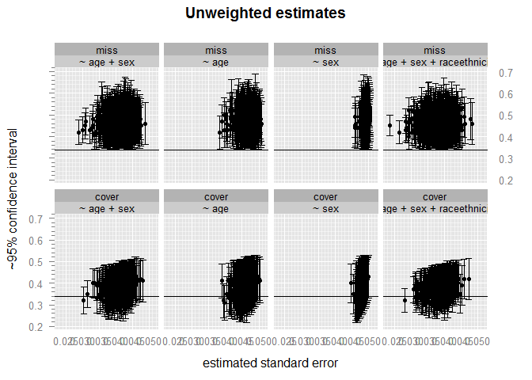

```r
z <- subset(estimates_df, weight == 'raw')

segplot(jitter(se) ~ I(est + 2*se) + I(est - 2*se) | stratification+cover,
        data = z,
        main = 'Unweighted estimates',
        ylab = '~95% confidence interval',
        xlab = 'estimated standard error',
        horizontal = FALSE,
        draw.bands = FALSE, centers = est, groups = cover,
        segments.fun = panel.arrows, ends = "both", auto.key = T,
        angle = 90, length = 1, unit = "mm")+ layer(panel.abline(h=true.mean))
```

```r
tab(z, ~ stratification + cover, pct = 1)
```

```
                             cover
stratification                 cover   miss  Total
  ~ age + sex                  37.70  62.30 100.00
  ~ age                        48.20  51.80 100.00
  ~ sex                        49.90  50.10 100.00
  ~ age + sex + raceethnicity  34.00  66.00 100.00
  All                          42.45  57.55 100.00
```

## Horvitz-Thompson weights

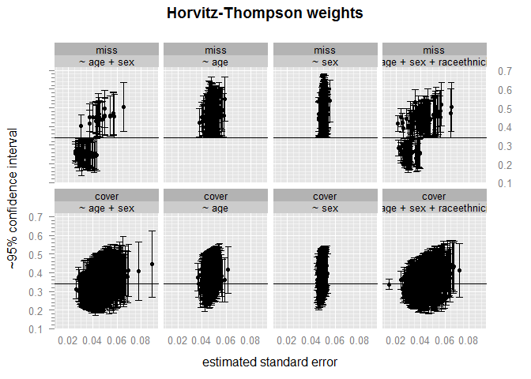

```r
z <- subset(estimates_df, weight == 'HT')

segplot(jitter(se) ~ I(est + 2*se) + I(est - 2*se) | stratification*cover,
        data = z,
        main = 'Horvitz-Thompson weights',
        ylab = '~95% confidence interval',
        xlab = 'estimated standard error',
        horizontal = FALSE,
        draw.bands = FALSE, centers = est, groups = cover,
        segments.fun = panel.arrows, ends = "both", auto.key = T,
        angle = 90, length = 1, unit = "mm")+ layer(panel.abline(h=true.mean))
```

```r
tab(z, ~ stratification + cover, pct = 1)
```

```
                             cover
stratification                  cover    miss   Total
  ~ age + sex                  91.000   9.000 100.000
  ~ age                        65.700  34.300 100.000
  ~ sex                        56.600  43.400 100.000
  ~ age + sex + raceethnicity  87.400  12.600 100.000
  All                          75.175  24.825 100.000
```

## Truncated Horvitz-Thompson weights

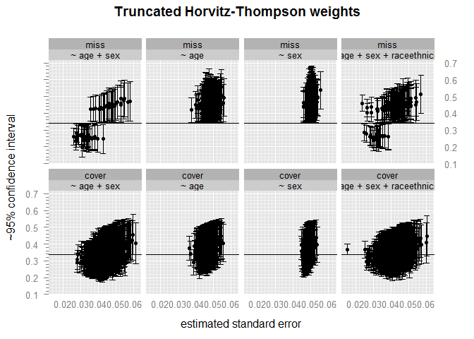

```r
z <- subset(estimates_df, weight == 'HTc')

segplot(jitter(se) ~ I(est + 2*se) + I(est - 2*se) | stratification*cover,
        data = z,
        ylab = '~95% confidence interval',
        xlab = 'estimated standard error',
        main = 'Truncated Horvitz-Thompson weights',
        horizontal = FALSE,
        draw.bands = FALSE, centers = est, groups = cover,
        segments.fun = panel.arrows, ends = "both", auto.key = T,
        angle = 90, length = 1, unit = "mm")+ layer(panel.abline(h=true.mean))
```

```r
tab(z, ~ stratification + cover, pct = 1)
```

```
                             cover
stratification                 cover   miss  Total
  ~ age + sex                  93.70   6.30 100.00
  ~ age                        65.50  34.50 100.00
  ~ sex                        56.60  43.40 100.00
  ~ age + sex + raceethnicity  86.80  13.20 100.00
  All                          75.65  24.35 100.00
```